# Homework-2019.09.20

# Homework 6

## Exercise 7.6

Efronand Tibshirani discuss the scor (bootstrap) test score data on 88 students who took examinations in five subjects [84, Table 7.1], [188, Table 1.2.1]. The first two tests (mechanics, vectors) were closed book and the last three tests (algebra, analysis, statistics) were open book. Each row of the data frame is a set of scores $(x_{i1},\cdots,x_{i5})$ for the $i^{th}$ student. Use a panel display to display the scatter plots for each pair of test scores. Compare the plot with the sample correlation matrix. Obtain bootstrap estimates of the standard errors for each of the following estimates: $\hat{\rho }_{12}=\hat{\rho}(mec, vec)$, $\hat{\rho }_{34}=\hat{\rho}(alg,ana)$, $\hat{\rho }_{35}=\hat{\rho}(alg, sta)$, $\hat{\rho }_{45}=\hat{\rho}(ana, sta)$.

## Project 7.B

Repeat Project 7.A for the sample skewness statistic. Compare the coverage rates for normal populations (skewness 0) and $\chi^2(5)$ distributions (positive skewness). ## Project 7.A Conduct a Monte Carlo study to estimate the coverage probabilities of the standard normal bootstrap confidence interval, the basic bootstrap confidence interval, and the percentile confidence interval. Sample from a normal population and check the empirical coverage rates for the sample mean. Find the proportion of times that the confidence intervals miss on the left, and the porportion of times that the confidence intervals miss on the right.

## Answer:

##7.6

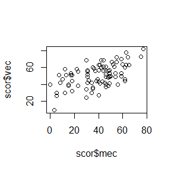

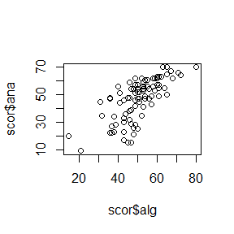

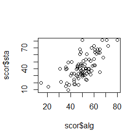

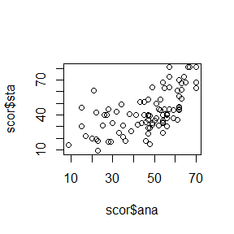

```r
library(bootstrap)
data(scor)
#par(mfrow=c(2,2))
plot(scor$mec,scor$vec);plot(scor$alg,scor$ana);plot(scor$alg,scor$sta);plot(scor$ana,scor$sta)
```

```r
cor(scor)
```

```
##           mec       vec       alg       ana       sta
## mec 1.0000000 0.5534052 0.5467511 0.4093920 0.3890993
## vec 0.5534052 1.0000000 0.6096447 0.4850813 0.4364487
## alg 0.5467511 0.6096447 1.0000000 0.7108059 0.6647357
## ana 0.4093920 0.4850813 0.7108059 1.0000000 0.6071743
## sta 0.3890993 0.4364487 0.6647357 0.6071743 1.0000000
```

```r
p<-cor(scor)
p_hat<-c(p[1,2],p[3,4],p[3,5],p[4,5])
B<-2000
n<-dim(scor)[1]
p_boot<-matrix(0,B,4)
for ( i in 1:B){
  n<-sample(1:88,88,replace = TRUE)
  p<-cor(scor[n,])
  p_boot[i,]<-c(p[1,2],p[3,4],p[3,5],p[4,5])
}
sd_hat<-function(p_boot){
  apply(p_boot,2,function(x) sqrt(var(x)))
}
p<-t(as.matrix(sd_hat(p_boot)))
rownames(p)<-"standard error"
colnames(p)<-c("12","34","35","45")
print(knitr::kable(p),type="latex")
```

|  | 12 | 34 | 35 | 45 |
| --- | --- | --- | --- | --- |
| standard error | 0.0779709 | 0.0483969 | 0.0593939 | 0.069444 |

## 7.B

```r
set.seed(01)
n<-20
B<-1e3
M<-1e3
alpha<-.05
ske_hat<-function(x) mean((x-mean(x))^3)/((n-1)*var(x)/n)^(3/2)
#x<-rnorm(n)
#y<-rchisq(n,5)

CI_est<-function(x,y){
ske_boot<-matrix(0,B,2)
##  Bootstrap estimation of skewness
for (i in 1:B){
  n1<-sample(1:n,n,replace = TRUE)
  x1<-x[n1]
  y1<-y[n1]
  ske_boot[i,]<-c(ske_hat(x1),ske_hat(y1))
}
##Normal Interval
sd<-sd_hat(ske_boot)
CI<-list()
CI$NI_x<-c(ske_hat(x)-qnorm(1-alpha/2)*sd[1],ske_hat(x)+qnorm(1-alpha/2)*sd[1])
CI$NI_y<-c(ske_hat(y)-qnorm(1-alpha/2)*sd[2],ske_hat(y)+qnorm(1-alpha/2)*sd[2])
##Percentile Interval
CI$PI_x<-quantile(ske_boot[,1],c(alpha/2,1-alpha/2))
CI$PI_y<-quantile(ske_boot[,2],c(alpha/2,1-alpha/2))
## Basic Interval
CI$BI_x<-c(2*ske_hat(x)-CI$PI_x[2],2*ske_hat(x)-CI$PI_x[1])
CI$BI_y<-c(2*ske_hat(y)-CI$PI_y[2],2*ske_hat(y)-CI$PI_y[1])
return (CI)
}
chi_ske<-4/sqrt(10)
rc<-matrix(0,M,6)
re<-matrix(0,M,6)
for (i in 1:M){
  x<-rnorm(n)
  y<-rchisq(n,5)
  CI<-CI_est(x,y)
  rc[i,1]<-0>=CI$NI_x[1]&&0<=CI$NI_x[2]
  rc[i,2]<-0>=CI$PI_x[1]&&0<=CI$PI_x[2]
  rc[i,3]<-0>=CI$BI_x[1]&&0<=CI$BI_x[2]
  rc[i,4]<-chi_ske>=CI$NI_y[1]&&chi_ske<=CI$NI_y[2]
  rc[i,5]<-chi_ske>=CI$PI_y[1]&&chi_ske<=CI$PI_y[2]
  rc[i,6]<-chi_ske>=CI$BI_y[1]&&chi_ske<=CI$BI_y[2]
}
p<-apply(rc,2,mean)
m<-matrix(p,2,3,byrow=TRUE)
rownames(m)<-c("normal","chi(5)")
colnames(m)<-c("Normal Interval","Percentile Interval","Basic Interval")
print(knitr::kable(m),type="latex")
```

|  | Normal Interval | Percentile Interval | Basic Interval |
| --- | --- | --- | --- |
| normal | 0.940 | 0.974 | 0.864 |
| chi(5) | 0.722 | 0.700 | 0.690 |

# Homework 7

## Exercise 7.8

Refer to Exercise 7.7. Obtain the jackknife estimates of bias and standard error of $\hat{\theta}$

## Exercise 7.7:

Refer to Exercise 7.6. Efron and Tibshirani discuss the following example [84, Ch. 7]. The five-dimensional scores data have a $5 \times 5$ covariance matrix $\Sigma$, with positive eigenvalues $\lambda_1>\cdots>\lambda_5$. In principal components analysis, $\theta =\frac{\lambda _1}{\sum_{j=1}^{5}\lambda _j}$ measures the proportion of variance explained by the first principal component. Let $\hat{\lambda_1}>\cdots>\hat{\lambda_5}$ be the eigenvalues of $\hat{\Sigma}$, where $\hat{\Sigma}$ is the MLE of $\Sigma$. Compute the sample estimate $\hat\theta =\frac{\hat{\lambda _1}}{\sum_{j=1}^{5}\hat{\lambda _j}}$ of $\theta$. Use bootstrap to estimate the bias and standard error of $\hat{\theta}$.

## Answer.

## Exercise 7.8

### (1) Firstly,define function to estimate Parameter.

```r
set.seed(1)
library(bootstrap)
theta_hat<-function(x){
  n<-dim(x)[1]
  y<-(n/(n-1))*cov(x)
  lambda<-eigen(y)$values
  theta=lambda[1]/sum(lambda)
  return(theta)
}
```

### Estimate bias and standard deviation via jackknife.

```r
n_row<-nrow(scor)
## Get estimation vector via jackknife.
theta_j<-vector(length=n_row)
for(i in 1:n_row){
  x<-scor[-i,]
  theta_j[i]<-theta_hat(x)
}
## Estimate bias of theta_hat
bias_hat_jack<-(n_row-1)*(mean(theta_j)-theta_hat(scor))
bias_hat_jack
```

```
## [1] 0.001069139
```

```r
## Estimate standard deviation of theta_hat
se_hat_jack<-sqrt((n_row-1)/n_row*sum((theta_j-mean(theta_j))^2))
se_hat_jack
```

```
## [1] 0.04955231
```

### Estimate bias and standard deviation via bootstrap

```r
set.seed(0)
## Get estimation vector via bootstrap
B<-2000
theta_b<-vector(length=B)
for (b in 1:B){
  i <- sample(1:n_row, size = n_row, replace = TRUE)
  x<-scor[i,]
  theta_b[b]<-theta_hat(x)
}
## Estimate deviation of theta_hat
bias_hat_boot<-(mean(theta_b)-theta_hat(scor))
bias_hat_boot
```

```
## [1] 0.00141022
```

```r
## Estimate standard deviation of theta_hat
se_hat_boot<-sqrt(1/B*sum((theta_b-mean(theta_b))^2))
se_hat_boot
```

```
## [1] 0.04697861
```

## Exercise 7.10:

In Example 7.18, leave-one-out (n-fold) cross validation was used to select the best fitting model. Repeat the analysis replacing the Log-Log model with a cubic polynomial model. Which of the four models is selected by the cross validation procedure? Which model is selected according to maximum adjusted $R^2$?

### choose the model via Cross validation.

```r
library(DAAG)
magnetic<-ironslag$magnetic
chemical<-ironslag$chemical
n <- length(magnetic) #in DAAG ironslag
e1 <- e2 <- e3 <- e4 <- numeric(n)

# for n-fold cross validation
# fit models on leave-one-out samples
for (k in 1:n) {
y <- magnetic[-k]
x <- chemical[-k]

J1 <- lm(y ~ x)
yhat1 <- predict.lm(J1,newdata = data.frame(x=chemical[k]))
e1[k] <- magnetic[k] - yhat1


J2 <- lm(y ~ x + I(x^2))
yhat2<-predict.lm(J2,newdata = data.frame(x=chemical[k]))
e2[k] <- magnetic[k] - yhat2

J3 <- lm(log(y) ~ x)
logyhat3 <-predict.lm(J3,newdata = data.frame(x=chemical[k]))
yhat3 <- exp(logyhat3)
e3[k] <- magnetic[k] - yhat3


J4 <- lm(y ~ x+I(x^2)+I(x^3))
yhat4<-predict.lm(J4,newdata = data.frame(x=chemical[k]))
e4[k] <- magnetic[k] - yhat4

}
c(mean(e1^2), mean(e2^2), mean(e3^2), mean(e4^2))
```

```
## [1] 19.55644 17.85248 18.44188 18.17756
```

```r
J <- lm(magnetic ~ chemical+I(chemical^2)+I(chemical^3))
J
```

```
##
## Call:
## lm(formula = magnetic ~ chemical + I(chemical^2) + I(chemical^3))
##
## Coefficients:
##   (Intercept)       chemical  I(chemical^2)  I(chemical^3)
##      3.015851       1.918082      -0.107963       0.002551
```

According to the prediction error criterion, Model 2, the quadratic model, would be the best fit for the data.

### choose model via adjust $R^2$ .

```r
library(caret)
r<-numeric(4)
f<-function(x,k) 1-((n-1)*(1-x))/(n-k)
y <- magnetic
x <- chemical
J1 <- lm(y ~ x)
yhat1 <- predict.lm(J1,newdata = data.frame(x=x))
r[1]<-f(R2(y,yhat1),2)

J2 <- lm(y ~ x + I(x^2))
yhat2<-predict.lm(J2,newdata = data.frame(x=x))
r[2]<-f(R2(y,yhat2),3)

J3 <- lm(log(y) ~ x)
logyhat3 <-predict.lm(J3,newdata = data.frame(x=x))
yhat3 <- exp(logyhat3)
r[3]<-f(R2(y,yhat3),2)

J4 <- lm(y ~ x+I(x^2)+I(x^3))
yhat4<-predict.lm(J4,newdata = data.frame(x=x))
r[4]<-f(R2(y,yhat4),4)
r
```

```
## [1] 0.5281545 0.5768151 0.5624358 0.5740396
```

According to the adjusted $R^2$, Model 2, the quadratic model, would be the best fit for the data.

# Homework 8

## 8.3

The Count 5 test for equal variances in Section 6.4 is based on the maximum number of extreme points. Example 6.15 shows that the Count 5 criterion is not applicable for unequal sample sizes. Implement a permutation test for equal variance based on the maximum number of extreme points that applies when sample sizes are not necessarily equal.

```r
library(boot)
set.seed(11111)
count5test <- function(z,ix,sizes) {
n1 <- sizes[1]; n2 <- sizes[2]; n <- n1 + n2
if(is.vector(z)) z <- data.frame(z,0);z <- z[ix, ];
X<-z[1:n1,1]
Y<-z[(n1+1):n,1]
X <- X - mean(X)
Y <- Y - mean(Y)
outx <- sum(X > max(Y)) + sum(X < min(Y))
outy <- sum(Y > max(X)) + sum(Y < min(X))
return(max(c(outx, outy)))
}
mu1<-1
mu2<-0
sigma1<-2
sigma2<-2
n1<-10
n2<-20
x<-rnorm(n1,mu1,sigma1)
y<-rnorm(n2,mu2,sigma2)
z<-c(x,y)
N<-c(n1,n2)
boot.obj<-boot(z,statistic =count5test,R=999,sim="permutation",sizes=N)
ts <- c(boot.obj$t0,  boot.obj$t)
mean(boot.obj$t>=ts[1])
```

```
## [1] 0.1891892
```

For two sets samples equal varience, permutation test based on Count 5 can accept the null hypothesis.

## Slides page 31

- Power comparison (distance correlation test versus ball covariance test)

  Model 1: $Y=X/4+e$  
  Model 2: $Y=X/4\times e$  
  $X\sim N(0_2,I_2)$, $e\sim N(0_2,I_2)$, $X$ and $e$ are independent.

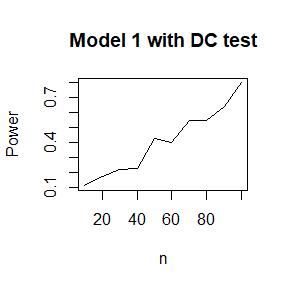

```r
library(mvtnorm)
library(Ball)
library(boot)
dCov <- function(x, y) {
x <- as.matrix(x); y <- as.matrix(y)
n <- nrow(x); m <- nrow(y)
if (n != m || n < 2) stop("Sample sizes must agree")
if (! (all(is.finite(c(x, y)))))
stop("Data contains missing or infinite values")
Akl <- function(x) {
d <- as.matrix(dist(x))
m <- rowMeans(d); M <- mean(d)
a <- sweep(d, 1, m); b <- sweep(a, 2, m)
b + M
}
A<- Akl(x); B <- Akl(y)
sqrt(mean(A * B))
}


ndCov2 <- function(z, ix, dims) {
#dims contains dimensions of x and y
p <- dims[1]
q <- dims[2]
d <- p + q
x <- z[ , 1:p] #leave x as is
y <- z[ix, -(1:p)] #permute rows of y
return(nrow(z) * dCov(x, y)^2)
}

# caculate the power with sample number n
power<-function(n,alpha){
  power_hat<-numeric(4)
  p_hat<-matrix(0,100,4)
  for (i in 1:100){
  set.seed(i*10)
  x1<-rmvnorm(n,c(0,0),diag(c(1,1)))
  e1<-rmvnorm(n,c(0,0),diag(c(1,1)))
  Y1<-x1/4+e1
  Y2<-x1*e1
  z1<-cbind(x1,Y1)
  z2<-cbind(x1,Y2)
  boot.obj <- boot(data = z1, statistic = ndCov2, R = 999,
  sim = "permutation", dims = c(2, 2))
  tb <- c(boot.obj$t0, boot.obj$t)
  p.cor <- mean(tb>=tb[1])
  p.ball <- bcov.test(z1[,1:2],z1[,3:4],R=999)$p.value

  boot.obj <- boot(data = z2, statistic = ndCov2, R = 999,
  sim = "permutation", dims = c(2, 2))
  tb <- c(boot.obj$t0, boot.obj$t)
  p.cor1 <- mean(tb>=tb[1])
  p.ball1 <- bcov.test(z2[,1:2],z2[,3:4],R=999)$p.value
  p_hat[i,]<-c(p.cor,p.ball,p.cor1,p.ball1)

}
  power_hat<-colMeans(p_hat<alpha)
  return(power_hat)
}

alpha<-0.05
power1<-matrix(0,10,4)
for(i in 1:10){
  power1[i,]<-power(i*10,alpha)


}
#par(mfrow=c(2,2))
plot(10*(1:10),power1[,1],type = "l",xlab = "n",ylab = "Power",main = "Model 1 with DC test")
```

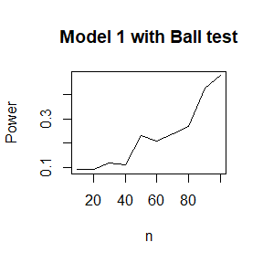

```r
plot(10*(1:10),power1[,2],type = "l",xlab = "n",ylab = "Power",main = "Model 1 with Ball test")
```

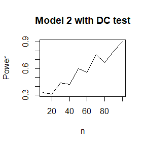

```r
plot(10*(1:10),power1[,3],type = "l",xlab = "n",ylab = "Power",main = "Model 2 with DC test")
```

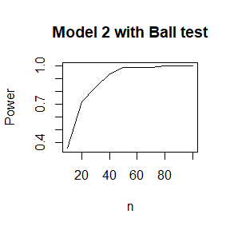

```r
plot(10*(1:10),power1[,4],type = "l",xlab = "n",ylab = "Power",main = "Model 2 with Ball test")
```

# Homework 9

## exercise 9.4

Implement a random walk Metropolis sampler for generating the standard Laplace distribution (see Exercise 3.2). For the increment, simulate from a normal distribution. Compare the chains generated when different variances are used for the proposal distribution. Also, compute the acceptance rates of each chain.

```r
f<-function(x) 1/2*exp(-abs(x))
#g<-function(x,sigma) dnorm(x,sd=sigma)
Rwms<-function(sigma,x0,N){
  x<-numeric(N)
  x[1]<-x0
  u<-runif(N)
   k <- 0
  for (i in 2:N) {
    y <- rnorm(1, x[i-1], sigma)
    if (u[i] <= ( f(y)/f(x[i-1]) ))
     x[i] <- y else {
     x[i] <- x[i-1]
     k <- k + 1
   }
  }
   plot(1:N,x,type="l",xlab = paste("sigma=",sigma),main=paste("acceptance rates=",(N-k)/N))
   abline(h=c(log(.05/2),-log(.05/2)))
   c<-list(x=x, k=k)
}
# par(mfrow=c(2,2))
#  sigma<-c(0.05,0.5,2,16)
#  for (i in 1:4){
#   Rwms(sigma[i],25,2000)
 # }
```

# Homework 10

## 1

## Exercises 11.1

The natural logarithm and exponential functions are inverses of each other, so that mathematically log(exp x) = exp(log x) = x. Show by example that this property does not hold exactly in computer arithmetic. Does the identity hold with near equality? (See all.equal.)

## Answer

```r
x<-c(2*(1:10),1000)
x1<-exp(log(x))
x2<-log(exp(x))
x1==x2
```

```
##  [1]  TRUE  TRUE  TRUE FALSE FALSE  TRUE FALSE FALSE FALSE FALSE FALSE
```

```r
mapply(function(x,y) isTRUE(all.equal(x,y)),x=x1,y=x2)
```

```
##  [1]  TRUE  TRUE  TRUE  TRUE  TRUE  TRUE  TRUE  TRUE  TRUE  TRUE FALSE
```

## 2

## Exercise 11.4

Find the intersection points A(k) in (0, $\sqrt{k}$) of the curves $S_{k-1}(a) = P(t(k-1) > \sqrt{\frac{a^2(k-1)}{k-a^2}})$ and $S_{k}(a) = P(t(k) > \sqrt{\frac{a^2(k)}{k+1-a^2}})$ for k = 4 : 25, 100, 500, 1000, where t(k) is a Student t random variable with k degrees of freedom. (These intersection points determine the critical values for a t-test for scale-mixture errors proposed by Szekely [260].)

## Exercises 11.5

Write a function to solve the equation $\frac{2\Gamma (\frac{k}{2})}{\sqrt{\pi(k-1)}\Gamma(\frac{k-1}{2})}\int_{0}^{c_{k-1}}(1+\frac{u^2}{k-1})^{-k/2}du$ = $\frac{2\Gamma (\frac{k+1}{2})}{\sqrt{\pi k}\Gamma (\frac{k}{2})}\int_{0}^{c_k}(1+\frac{u^2}{k})^{-(k+1)/2}du$ for a, where $c_k = \sqrt{\frac{a^2 k}{k+1-a^2}}$ compare the solutions with the points A(k) in Exercise 11.4

## Answer

## 11.4

```r
library(rootSolve)
k<-c(4:25,100,500,1000)
f<-function(x,k){
 pt(sqrt(x^2*k/(k+1-x^2)),df=k)-pt(sqrt(x^2*(k-1)/(k-x^2)),df=k-1)}
s<-sapply(k, function(k) {
  g<-function(x){
 return(pt(sqrt(x^2*k/(k+1-x^2)),df=k)-pt(sqrt(x^2*(k-1)/(k-x^2)),df=k-1))}
  uniroot(g,interval = c(1e-6,sqrt(k)-1e-6))$root
  })
s
```

```
##  [1]  1.492103  1.533549  1.562768  1.584421  1.601182  1.614517  1.625406
##  [8]  1.634409  1.642026  1.648511  1.654174  1.659121  1.663442  1.667288
## [15]  1.670736  1.673841  1.676589  1.679139  1.681461  4.795831  4.898978
## [22]  4.999999  9.999999 22.360679 31.622776
```

```r
# mapply(f,x=s,k=k)
```

## 11.5

```r
inte<-function(x,k){
  c<-2*gamma(k/2)/(sqrt(pi*(k-1))*gamma((k-1)/2))
  f<-function(u) (1+u^2/(k-1))^(-k/2)
  d<-c*integrate(f,0,sqrt(x^2*(k-1)/(k-x^2)),rel.tol=.Machine$double.eps^0.25)$value
  return(d)
}
k1<-4:25
s1<-sapply(k1, function(k) {
  g<-function(x) inte(x,k+1)-inte(x,k)
  uniroot(g,interval = c(1e-5,sqrt(k)-0.15))$root
  })
s1
```

```
##  [1] 1.492082 1.533559 1.562725 1.584429 1.601197 1.614517 1.625383 1.634380
##  [9] 1.642026 1.648546 1.654191 1.659102 1.663428 1.667286 1.670729 1.673826
## [17] 1.676632 1.679126 1.681454 1.683581 1.685538 1.687344
```

```r
k2<-100
s2<-sapply(k2, function(k) {
  g<-function(x) inte(x,k+1)-inte(x,k)
  uniroot(g,interval = c(1,sqrt(k)-3))$root
  })
s2
```

```
## [1] 1.720596
```

## 3

## A-B-O blood type problem

- Let the three alleles be A, B, and O with allele frequencies p, q, and r. The 6 genotype frequencies under HWE and complete counts are as follows.
  - Observed data: $n_{A\cdot}=n_{AA}+n_{AO}=28$ (A-type), $n_{B\cdot}=n_{BB}+n_{BO}=24$ (B-type), $n_{OO}=41$ (O-type), $n_{AB}=70$ (AB-type).
  - Use EM algorithm to solve MLE of $p$ and $q$ (consider missing data $n_{AA}$ and $n_{BB}$).
  - Record the log-maximum likelihood values in M-steps, are they increasing?

## Answer

```r
# p<-c(1/2,1/4,1/4)
# f<-function(x){
#   (c(x[1]^2,x[2]^2,x[3]^2,2*x[1]*x[3],2*x[2]*x[3],2*x[1]*x[3]))}
# d<-sample(1:6,150,replace = TRUE,prob=f(p))
# e<-sapply(1:6,function(x,d) {length(which(d==x))},d=d)
#nA<-e[1]+e[4];nB<-e[2]+e[5];nOO<-e[3];nAB<-e[6]
nA<-28;nB<-24;nOO<-41;nAB<-70
theta<-c(1/3,1/3,1/3);v<-1;L<-numeric(1)
n<-nA+nB+nOO+nAB
while (v<50){
  a1<-(theta[1]^2/((theta[1]^2)+2*theta[1]*theta[3]))
  a<-nA*(a1+1)+nAB
  b1<-(theta[2]^2/((theta[2]^2)+2*theta[2]*theta[3]))
  b<-nB*(b1+1)+nAB
  c<-2*nOO+nA+nB-a1*nA-b1*nB
  theta1<-c(a,b,c)/sum(c(a,b,c))
  l<-a*log(theta1[1])+b*log(theta1[2])+c*log(theta1[3])+log(2)*nA*(1-a1)+log(2)*nB*(1-b1)+log(factorial(n))-log(factorial(floor(nA*a1))*factorial(floor(nA-nA*a1))*factorial(floor(nB*b1))*factorial(floor(nB-nB*b1))*factorial(nAB)*factorial(nOO))
  L<-c(L,l)
  theta<-theta1
  v<-v+1
}
theta
```

```
## [1] 0.3273442 0.3104267 0.3622291
```

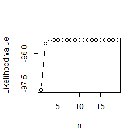

```r
plot(L[2:20],xlab="n",ylab="Likelihood value",type="b")
```

# Homework 11

## Exercise 3 (P204)

Use both for loops and lapply() to fit linear models to the mtcars using the formulas stored in this list:  
formulas <- list(  
mpg ~ disp,  
mpg ~ I(1 / disp),  
mpg ~ disp + wt,  
mpg ~ I(1 / disp) + wt  
)

```r
data("mtcars")
formulas <- list(
  mpg ~ disp,
  mpg ~ I(1 / disp),
  mpg ~ disp + wt,
  mpg ~ I(1 / disp) + wt
)
##use loops
result3.1<-list()
v<-1
for (i in formulas){
  fit<-lm(formula = i,data=mtcars)
  result3.1[[v]]<-fit
  v<-v+1
}
#use lapply
result3.2<-lapply(formulas, function(formulas){
  lm(formula = formulas,data = mtcars)
})
```

## Exercise 4 (P204)

Fit the model mpg ~ disp to each of the bootstrap replicates of mtcars in the list below by using a for loop and lapply(). Can you do it without an anonymous function?

```r
bootstraps <- lapply(1:10, function(i) {
  rows <- sample(1:nrow(mtcars), rep = TRUE)
  mtcars[rows, ]
})
## use for loop
result4.1<-list()
for (i in 1:10){
result4.1[[i]]<-lm(formula=mpg~disp,data=bootstraps[[i]])

}
## use lapply
result4.2<-lapply(bootstraps,function(x) lm(formula=mpg~disp,data=x))
```

## Exercise 5 (P204)

For each model in the previous two exercises, extract R2 using the function below.  
rsq <- function(mod) summary(mod)$r.squared

```r
rsq <- function(mod) summary(mod)$r.squared
R_3.1<-lapply(result3.1, rsq)
R_3.2<-lapply(result3.2, rsq)
R_4.1<-lapply(result4.1, rsq)
R_4.2<-lapply(result4.2, rsq)
```

## Exercise 3 (P214)

The following code simulates the performance of a t-test for non-normal data. Use sapply() and an anonymous function to extract the p-value from every trial.  
trials <- replicate(100, t.test(rpois(10, 10), rpois(7, 10)), simplify = FALSE)  
Extra challenge: get rid of the anonymous function by using [[ directly.

```r
trials <- replicate(100, t.test(rpois(10, 10), rpois(7, 10)), simplify = FALSE)
p1<-sapply(trials, function(x) x$p.value)
p2<-numeric(100)
for (i in 1:100){
p2[i]<-trials[[i]]$p.value
}
```

## Exercise 7 (P214)

Implement mcsapply(), a multicore version of sapply(). Can you implement mcvapply(), a parallel version of vapply()? Why or why not?

```r
library(parallel)
f<-function(x) c(mean(x),sd(x),mad(x))
g<-function(x) x^2
x<-list(1:10,20:30,c(TRUE,FALSE,TRUE,TRUE))
# mcsapply()
mcsapply<-function(k,f){
  cl <- makeCluster(4)
  result<-parLapply(cl,k,f)
  stopCluster(cl)
  return(unlist(result))
}
system.time(cc<-mcsapply(1:100,g))
```

```
## 用户 系统 流逝
## 0.00 0.01 1.13
```

```r
vapply(x,f,c(1,2,3))
```

```
##         [,1]      [,2] [,3]
## [1,] 5.50000 25.000000 0.75
## [2,] 3.02765  3.316625 0.50
## [3,] 3.70650  4.447800 0.00
```

I think it is possible to implement mcvapply(),we just need to compare the type of each result and the given FUN.VALUE .Then ,choose the highest type as the output of result.

# Homework 12

## Answer

```r
#  R function
library(SC19056)
library(microbenchmark)
Rwms<-function(sigma,x0,N){
x<-matrix(NA,N,2);x[1,]<-c(x0,0);u<-runif(N)
for (i in 2:N) {
y <- rnorm(1, x[i-1,1], sigma)
c1=1/2*exp(-abs(y))
c2=1/2*exp(-abs(x[i-1,1]))
if (u[i] <= ( c1/c2 )){
x[i,1] <- y ;x[i,2]<-1}
else {
x[i,1] <- x[i-1,1];x[i,2]<-0
}
}
return(x)
}
# Question one:
ts <- microbenchmark(R=Rwms(1,25,10000), Cpp=RwmsC(1,25,10000))
summary(ts)[,c(1,3,5,6)]
```

```
##   expr      lq    median        uq
## 1    R 21.0531 22.041652 25.799751
## 2  Cpp  1.2832  1.313951  1.396702
```

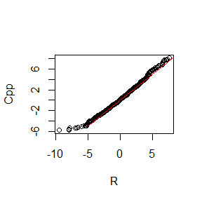

```r
# Question two:
set.seed(13)
c<-Rwms(1,5,10000)
R<-c[which(c[,2]==1),1]
c1<-RwmsC(1,5,10000)
Cpp<-c1[which(c[,2]==1),1]
qqplot(R,Cpp)
points(x=seq(-5,10,length.out = 100),y=seq(-5,10,length.out = 100),type = "l",col=2)
```

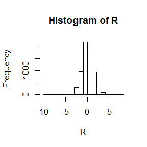

```r
# Result
#par(mfrow=c(1,2))
hist(R)
```

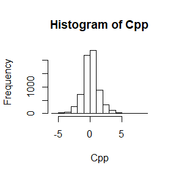

```r
hist(Cpp)
```

From the results above,we find the distributions of samples that selected via R function and Cpp function is almost the same.But Cpp perform better than R function in terms of time.